# Atividades de Econometria

Clevia Bento de Oliveira

13/12/2021

# Atividade 1

Análise de regressão linear simples com o banco de dados fornecido na aula 1.

### Objetivo: avaliar se o consumo aumenta a medida em que a renda cresce.

Y= consumo (Variável dependente)  
X= renda (Variável independente)

#### Carregamento do banco de dados

```r
require(pacman)
pacman::p_load(dplyr, ggplot2, car, rstatix, lmtest, ggpubr)
library(readxl)

dados <- read_excel("C:/Users/Clevia/Documents/Econometria/econometria-dados.xlsx")
glimpse(dados)
```

```
## Rows: 15
## Columns: 3
## $ ano <dbl> 1982, 1983, 1984, 1985, 1986, 1987, 1988, 1989, 1990, 1991, 1992, ~
## $ y   <chr> "3081.5", "3240.6", "3407.6", "3566.5", "3708.7", "3822.3", "3972.~
## $ x   <chr> "4620.3", "4803.7", "5140.1", "5323.5", "5487.7", "5649.5", "5865.~
```

```r
dados$y <- as.numeric(dados$y)
dados$x <- as.numeric(dados$x)
```

### Verificação dos pressupostos para a regressão linear

Relação linear entre a variável dependente (y), e independente (x).

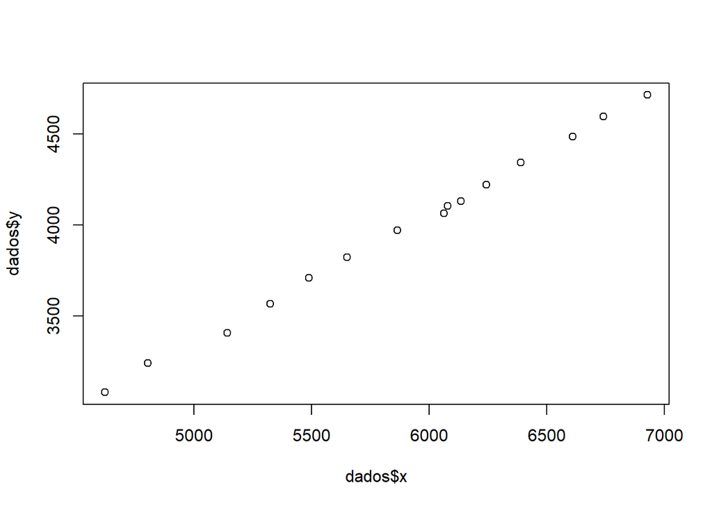

```r
plot(dados$x, dados$y)
```

Analisando o gráfico, podemos ver que os dados possuem uma relação linear

### Construção do modelo

```r
mod <- lm(y ~ x, dados)
```

### Análise gráfica

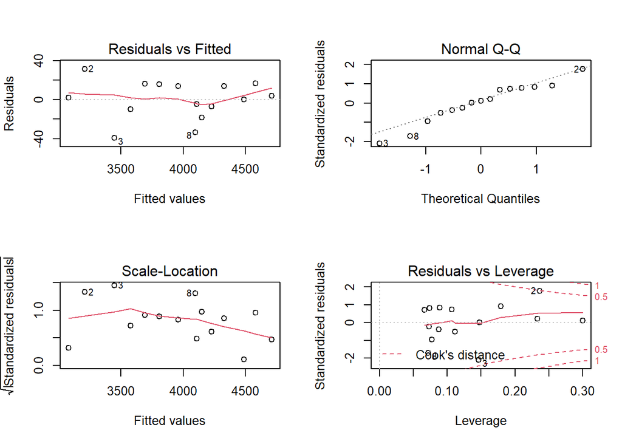

```r
par(mfrow=c(2,2))

plot(mod)
```

```r
par(mfrow=c(1,1))
```

O primeiro gráfico é o gráfico de resíduos pelos valores previstos,vemos que a linha vermelha está próxima à linha pontilhada então podemos concluir que de fato dos dados possuem linearidade.  
Também é possível ver a presença de homocedasticidade.  
No segundo gráfico verificamos se os resíduos possuem distribuição normal,neste caso vemos que os resíduos estão bem próximos à linha indicando que há indícios de uma distribuição normal.  
No ultimo gráfico verificamos se há outliers e se eles são pontos influentes.

## Normalidade dos resíduos:

Para o teste de shapiro temos:  
H0: os dados possuem distribuição normal  
H1: os dados não possuem distribuição normal

```r
shapiro.test(mod$residuals)
```

```
##
##  Shapiro-Wilk normality test
##
## data:  mod$residuals
## W = 0.94445, p-value = 0.4416
```

Vemos que o p-valor foi maior que 0,05 então concluímos que os resíduos possuem distribuição normal

## Outliers nos resíduos:

Verificando o resumo dos resíduos padronizados vemos que os dados estão dentro do intervalo [-3,3] e a mediana próxima de zero então concluímos que não há outliers

```r
summary(rstandard(mod))
```

```
##     Min.  1st Qu.   Median     Mean  3rd Qu.     Max.
## -2.09862 -0.44729  0.10375  0.01132  0.76310  1.76637
```

## Independência dos resíduos (Durbin-Watson):

Vemos que a estatística de Durbin-Watson está próxima de 2 então podemos concluir que os dados possuem independencia

```r
durbinWatsonTest(mod)
```

```
##  lag Autocorrelation D-W Statistic p-value
##    1     -0.04262691       2.08183    0.91
##  Alternative hypothesis: rho != 0
```

## Homocedasticidade (Breusch-Pagan):

H0: há homocedasticidade  
H1: não há homocedasticidade

```r
bptest(mod)
```

```
##
##  studentized Breusch-Pagan test
##
## data:  mod
## BP = 2.0826, df = 1, p-value = 0.149
```

## Análise do modelo

```r
summary(mod)
```

```
##
## Call:
## lm(formula = y ~ x, data = dados)
##
## Residuals:
##     Min      1Q  Median      3Q     Max
## -39.330  -8.601   1.761  14.769  31.306
##
## Coefficients:
##               Estimate Std. Error t value Pr(>|t|)
## (Intercept) -1.841e+02  4.626e+01  -3.979  0.00157 **
## x            7.064e-01  7.827e-03  90.247  < 2e-16 ***
## ---
## Signif. codes:  0 '***' 0.001 '**' 0.01 '*' 0.05 '.' 0.1 ' ' 1
##
## Residual standard error: 20.29 on 13 degrees of freedom
## Multiple R-squared:  0.9984, Adjusted R-squared:  0.9983
## F-statistic:  8145 on 1 and 13 DF,  p-value: < 2.2e-16
```

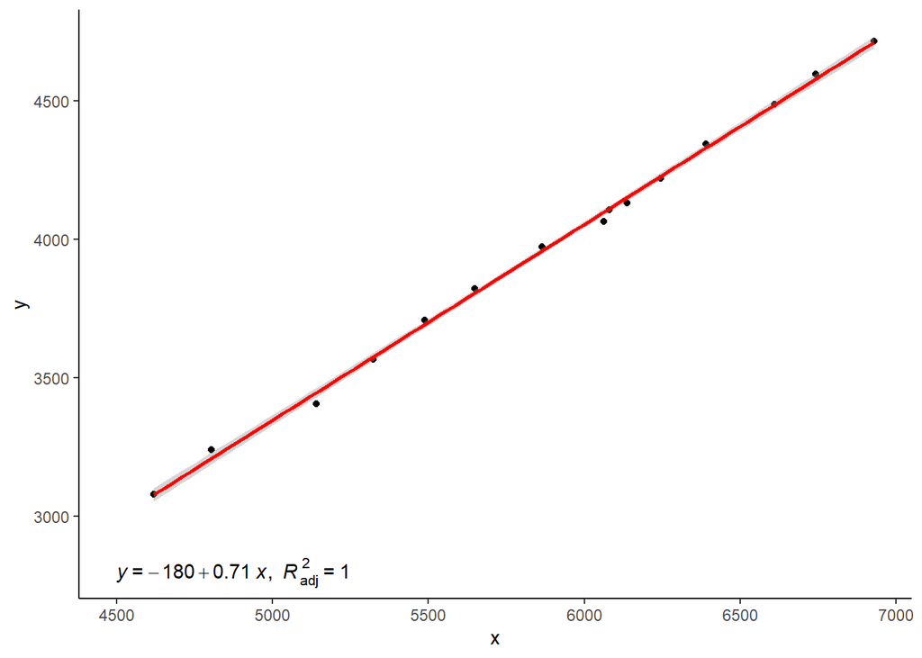

```r
ggplot(data = dados, mapping = aes(x = x, y = y)) +
  geom_point() +
  geom_smooth(method = "lm", col = "red") +
  stat_regline_equation(aes(label = paste(..eq.label.., ..adj.rr.label..,
                                          sep = "*plain(\",\")~~")),
                        label.x = 4500, label.y = 2800) +
  theme_classic()
```

# Atividade 2

## carregamento do banco de dados

```r
dados2 <- read_excel("C:/Users/Clevia/Documents/Econometria/econometria-dadosatv2.xlsx")
glimpse(dados2)
```

```
## Rows: 60
## Columns: 2
## $ x <dbl> 80, 80, 80, 80, 80, 100, 100, 100, 100, 100, 100, 120, 120, 120, 120~
## $ y <dbl> 55, 60, 65, 70, 75, 65, 70, 74, 80, 85, 88, 79, 84, 90, 94, 98, 80, ~
```

#Verificação dos presupostos

Relação linear entre a Variável dependente (y) e a independente (x):

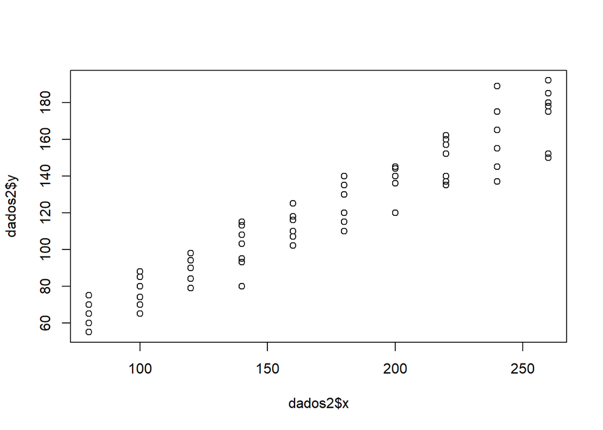

```r
plot(dados2$x, dados2$y)
```

## Construção do modelo:

```r
mod1 <- lm(y ~ x, dados2)
```

## Análise gráfica:

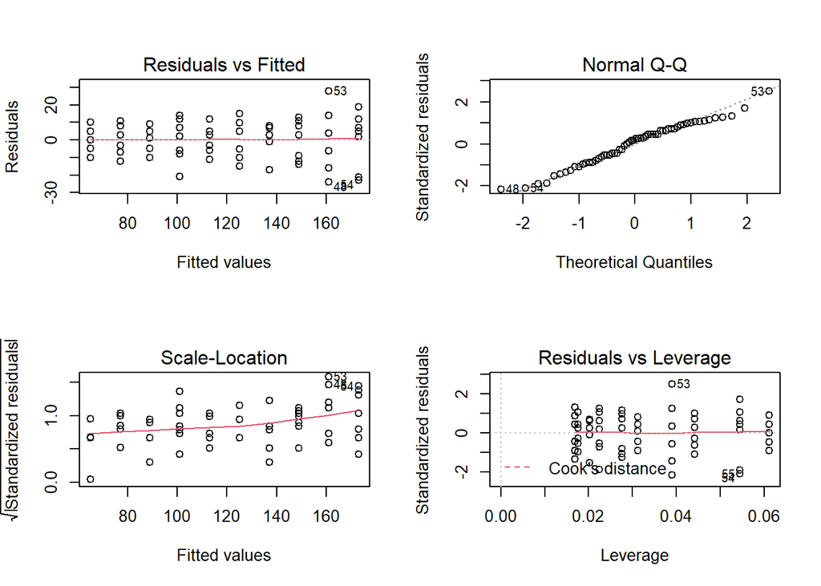

```r
par(mfrow=c(2,2))

plot(mod1)
```

```r
par(mfrow=c(1,1))
```

## Normalidade dos resíduos:

```r
shapiro.test(mod1$residuals)
```

```
##
##  Shapiro-Wilk normality test
##
## data:  mod1$residuals
## W = 0.97772, p-value = 0.3397
```

os resíduos seguem distribuição normal

## Outliers nos resíduos:

```r
summary(rstandard(mod1))
```

```
##       Min.    1st Qu.     Median       Mean    3rd Qu.       Max.
## -2.1615027 -0.7367773  0.2213231  0.0000174  0.7143167  2.5128509
```

não há presença de outliers

## Independência dos resíduos (Durbin-Watson):

```r
durbinWatsonTest(mod1)
```

```
##  lag Autocorrelation D-W Statistic p-value
##    1       0.2166147       1.50539   0.046
##  Alternative hypothesis: rho != 0
```

## Homocedasticidade (Breusch-Pagan):

```r
bptest(mod1)
```

```
##
##  studentized Breusch-Pagan test
##
## data:  mod1
## BP = 9.0378, df = 1, p-value = 0.002645
```

não há homocedasticidade

#Análise do modelo

```r
summary(mod1)
```

```
##
## Call:
## lm(formula = y ~ x, data = dados2)
##
## Residuals:
##     Min      1Q  Median      3Q     Max
## -24.046  -8.261   2.481   7.983  27.954
##
## Coefficients:
##             Estimate Std. Error t value Pr(>|t|)
## (Intercept) 16.94063    4.67354   3.625 0.000611 ***
## x            0.60044    0.02555  23.496  < 2e-16 ***
## ---
## Signif. codes:  0 '***' 0.001 '**' 0.01 '*' 0.05 '.' 0.1 ' ' 1
##
## Residual standard error: 11.35 on 58 degrees of freedom
## Multiple R-squared:  0.9049, Adjusted R-squared:  0.9033
## F-statistic: 552.1 on 1 and 58 DF,  p-value: < 2.2e-16
```

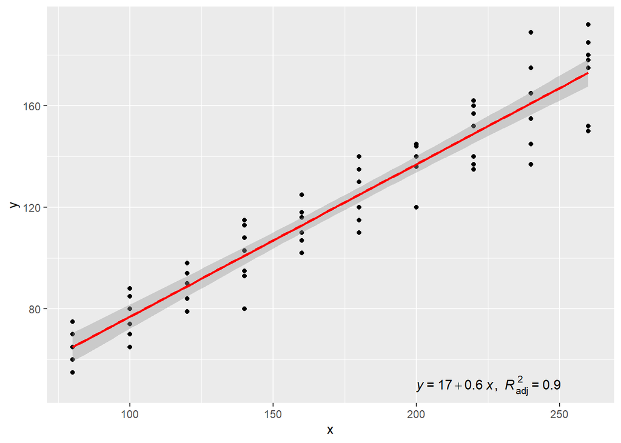

```r
ggplot(data = dados2, mapping = aes(x = x, y = y)) +
  geom_point() +
  geom_smooth(method = "lm", col = "red") +
  stat_regline_equation(aes(label = paste(..eq.label.., ..adj.rr.label..,
                                          sep = "*plain(\",\")~~")),
                        label.x = 200, label.y = 50) +
  theme_get()
```

# Atividade 3: Multicolinearidade

## Carregando os dados

```r
dados3 <- read_excel("C:/Users/Clevia/Documents/Econometria/atv 3 econometria.xlsx")
attach(dados3)
```

## Construção do modelo

```r
ajuste<- lm(CO2 ~ PIB + Pop, dados3)
ajuste
```

```
##
## Call:
## lm(formula = CO2 ~ PIB + Pop, data = dados3)
##
## Coefficients:
## (Intercept)          PIB          Pop
##     0.47234      0.03048      0.02757
```

## Anova

```r
anova(ajuste)
```

```
## Analysis of Variance Table
##
## Response: CO2
##           Df Sum Sq Mean Sq F value   Pr(>F)
## PIB        1 63.771  63.771 17.5621 0.008566 **
## Pop        1  0.122   0.122  0.0336 0.861772
## Residuals  5 18.156   3.631
## ---
## Signif. codes:  0 '***' 0.001 '**' 0.01 '*' 0.05 '.' 0.1 ' ' 1
```

## Analise gráfica

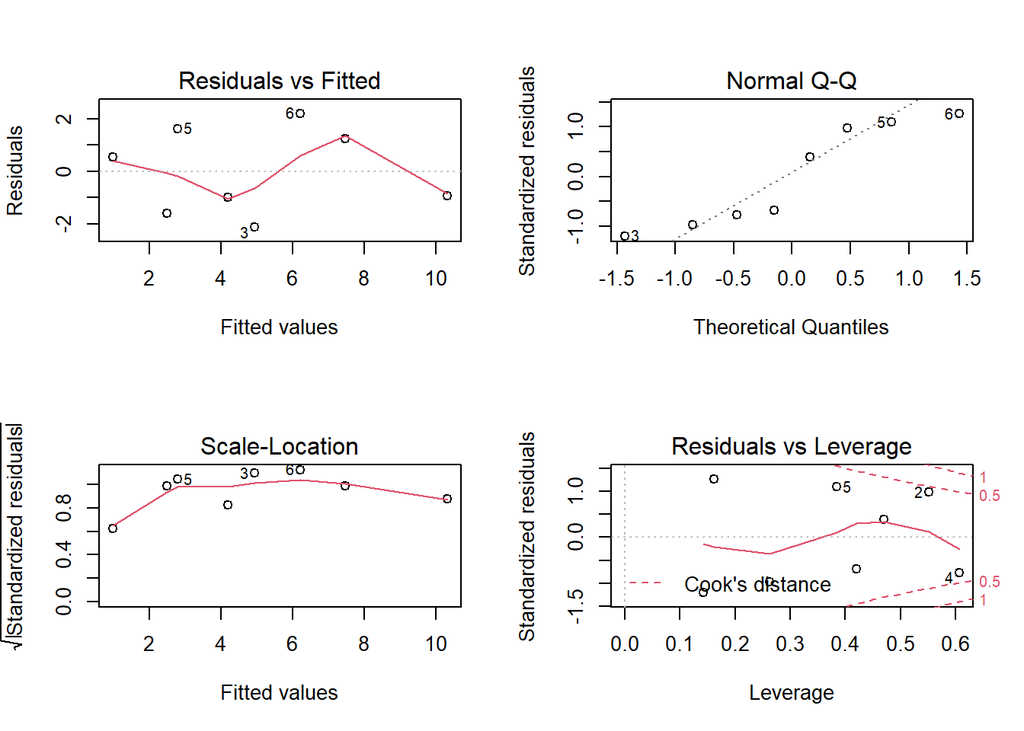

```r
par(mfrow=c(2,2))

plot(ajuste)
```

```r
par(mfrow=c(1,1))
```

## Correlação

```r
dados3_2<- dados3[,2:3]
cor(dados3_2)
```

```
##           PIB       Pop
## PIB 1.0000000 0.9426789
## Pop 0.9426789 1.0000000
```

vemos que as variavéis são altamente correlacionadas

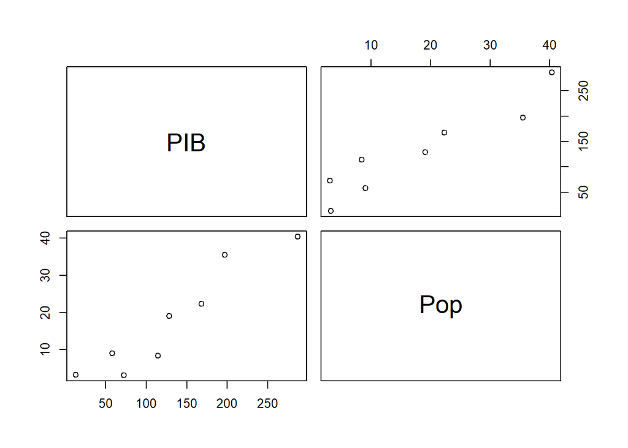

```r
pairs(dados3_2)
```

As variáveis possuem um relacionamento linear forte e positivo entre si

```r
summary(ajuste)
```

```
##
## Call:
## lm(formula = CO2 ~ PIB + Pop, data = dados3)
##
## Residuals:
##       1       2       3       4       5       6       7       8
##  0.5372  1.2452 -2.1181 -0.9145  1.6297  2.1990 -0.9903 -1.5881
##
## Coefficients:
##             Estimate Std. Error t value Pr(>|t|)
## (Intercept)  0.47234    1.32844   0.356    0.737
## PIB          0.03048    0.02486   1.226    0.275
## Pop          0.02757    0.15044   0.183    0.862
##
## Residual standard error: 1.906 on 5 degrees of freedom
## Multiple R-squared:  0.7787, Adjusted R-squared:  0.6902
## F-statistic: 8.798 on 2 and 5 DF,  p-value: 0.02303
```

```r
vif(ajuste)
```

```
##      PIB      Pop
## 8.980173 8.980173
```

## Conclusão

na anova a interação é significativa porém ao realizar os testes t as variáveis individualmente não são significativas, além disso as variáveis possuem uma forte correlação e o valor de VIF apesar de não ser maior que 10, está bastante próximo desse valor. Então concluímos que há multicolinearidade.